--- title: "Lab 04" author: "Yukun Guo" date: 2022-04-27 categories: ["R"] tags: ["R Markdown", "plot", "regression"] ---

# Lab 4 Deliverable

Yukun Guo

4/27/2022

# Lab 4 Deliverable

## Part 1: Tidying

```r
gapmnd_un_tidy <- read_excel('data/gapminder_broadband_per_100.xlsx')
gapmnd <- gapmnd_un_tidy|> janitor::clean_names()
colnames(gapmnd)[1] <- 'country'
gapmnd
```

```
## # A tibble: 213 × 15
##    country         x1998 x1999 x2000    x2001   x2002    x2003    x2004    x2005
##    <chr>           <dbl> <dbl> <dbl>    <dbl>   <dbl>    <dbl>    <dbl>    <dbl>
##  1 Afghanistan        NA    NA    NA  0       0        0        6.88e-4  7.36e-4
##  2 Albania            NA    NA    NA  0       0        0        0        8.66e-3
##  3 Algeria            NA    NA    NA  0       0        5.64e-2  1.11e-1  4.10e-1
##  4 American Samoa     NA    NA    NA  0       0       NA       NA       NA
##  5 Andorra            NA    NA    NA NA       1.66e+0  4.99e+0  8.34e+0  1.33e+1
##  6 Angola             NA    NA    NA  0       0        0        0        0
##  7 Antigua and Ba…    NA    NA    NA  0       0        0        1.21e-1  9.38e-1
##  8 Argentina           0    NA    NA  2.52e-1 3.93e-1  6.81e-1  1.42e+0  2.40e+0
##  9 Armenia            NA    NA    NA  1.96e-4 2.61e-4  3.27e-4  3.27e-2  6.49e-2
## 10 Aruba              NA    NA    NA  0       0        1.44e+0  7.03e+0  1.22e+1
## # … with 203 more rows, and 6 more variables: x2006 <dbl>, x2007 <dbl>,
## #   x2008 <dbl>, x2009 <dbl>, x2010 <dbl>, x2011 <lgl>
```

```r
gapmnd |>
  pivot_longer(-country,names_to = 'year',values_to="broadband") |>
  drop_na()
```

```
## # A tibble: 2,108 × 3
##    country     year  broadband
##    <chr>       <chr>     <dbl>
##  1 Afghanistan x2001  0
##  2 Afghanistan x2002  0
##  3 Afghanistan x2003  0
##  4 Afghanistan x2004  0.000688
##  5 Afghanistan x2005  0.000736
##  6 Afghanistan x2006  0.00163
##  7 Afghanistan x2007  0.00158
##  8 Afghanistan x2008  0.00154
##  9 Afghanistan x2009  0.00299
## 10 Afghanistan x2010  0.00436
## # … with 2,098 more rows
```

```r
#gapmnd$continent <- countrycode(sourcevar = gapmnd$country,
#                            origin = "country.name",
#                            destination = "continent")
```

## Part 2: Gapminder

Recall the Task Menu:

- Get the maximum and minimum of GDP per capita for all continents.
- Look at the spread of GDP per capita across countries within the continents.
- How does life expectancy vary across different continents?
- Report the absolute and/or relative abundance of countries with low life expectancy over time by continent: Compute some measure of worldwide life expectancy - you decide - a mean or median or some other quantile or perhaps your current age. Then determine how many countries on each continent have a life expectancy less than this benchmark, for each year.
- Make up your own!

### Get the maximum and minimum of GDP per capita for all continents.

#### Table

```r
gapmnd_gdp <-gapminder |>
  select(year, continent,gdpPercap)|>
  group_by(year,continent)|>
  summarise_if(is.numeric, funs(min,max),na.rm = TRUE)
gapmnd_gdp <- gapmnd_gdp|>pivot_longer(min:max, names_to = "Type", values_to="gdpPercap")
gapmnd_gdp
```

```
## # A tibble: 120 × 4
## # Groups:   year [12]
##     year continent Type  gdpPercap
##    <int> <fct>     <chr>     <dbl>
##  1  1952 Africa    min        299.
##  2  1952 Africa    max       4725.
##  3  1952 Americas  min       1398.
##  4  1952 Americas  max      13990.
##  5  1952 Asia      min        331
##  6  1952 Asia      max     108382.
##  7  1952 Europe    min        974.
##  8  1952 Europe    max      14734.
##  9  1952 Oceania   min      10040.
## 10  1952 Oceania   max      10557.
## # … with 110 more rows
```

#### Companion Graph

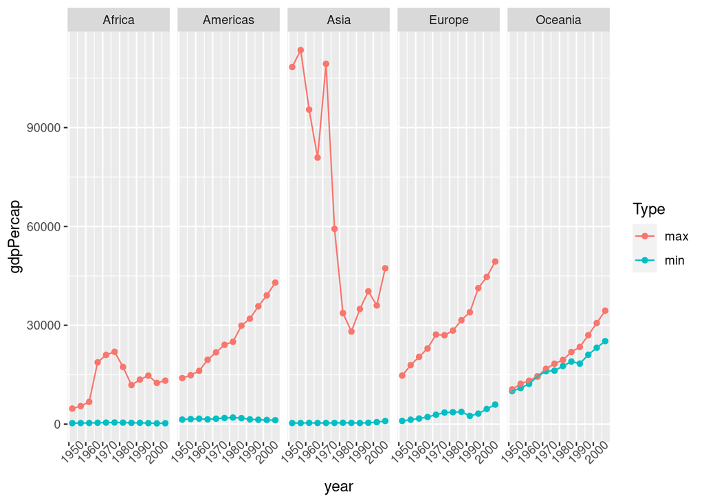

```r
 ggplot(gapmnd_gdp,aes(x=year,y=gdpPercap, color=Type))+
  geom_point()+
  geom_line(aes(group=Type))+theme(axis.text.x = element_text( angle = 45))+
  facet_wrap(~continent, ncol=5)
```

#### Description/Writeup

This plot shows the max and min GDP per capita for all continents and the change over year

### How does life expectancy vary across different continents?

#### Table

```r
df <-gapminder |>
  select(country,continent,year,lifeExp)
df
```

```
## # A tibble: 1,704 × 4
##    country     continent  year lifeExp
##    <fct>       <fct>     <int>   <dbl>
##  1 Afghanistan Asia       1952    28.8
##  2 Afghanistan Asia       1957    30.3
##  3 Afghanistan Asia       1962    32.0
##  4 Afghanistan Asia       1967    34.0
##  5 Afghanistan Asia       1972    36.1
##  6 Afghanistan Asia       1977    38.4
##  7 Afghanistan Asia       1982    39.9
##  8 Afghanistan Asia       1987    40.8
##  9 Afghanistan Asia       1992    41.7
## 10 Afghanistan Asia       1997    41.8
## # … with 1,694 more rows
```

#### Companion Graph

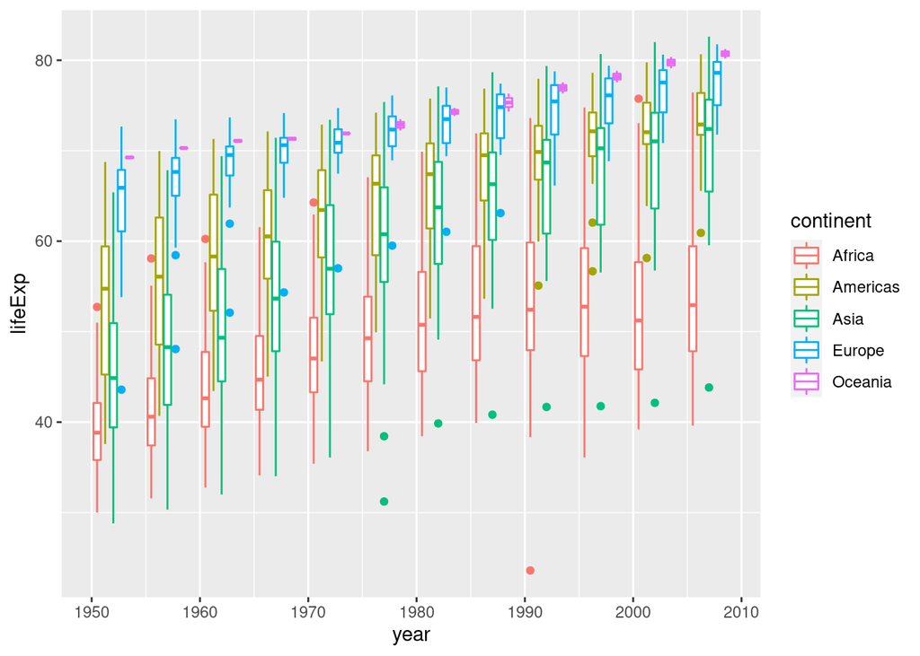

```r
ggplot(df,aes(x=year, y=lifeExp,group=interaction(continent, year),color=continent))+
  geom_boxplot()
```

#### Description/Writeup

This plot shows the life expectancy distribution for each continent over years.